# Disease Prediction Binary Classification Problem

# Importing Libraries

```python
import numpy as np
import pandas as pd
import matplotlib.pyplot as plt
import seaborn as sns
```

```python
from numpy.random import seed
seed(1)
import tensorflow as tf
tf.random.set_seed(2)
```

```python
from sklearn import preprocessing
from sklearn import metrics
from sklearn import svm
from sklearn.model_selection import train_test_split,GridSearchCV,RandomizedSearchCV,cross_val_score
import tensorflow as tf
from sklearn.linear_model import LogisticRegression
from sklearn.tree import DecisionTreeClassifier
from tensorflow.python.keras.wrappers.scikit_learn import KerasClassifier
from tensorflow.python.keras.models import Sequential
from tensorflow.python.keras.layers import Dense,Dropout
from tensorflow.python.keras.callbacks import EarlyStopping
from sklearn.metrics import classification_report,confusion_matrix,precision_score,recall_score,f1_score,roc_curve,roc_auc_score
```

```python
# Read train data

df = pd.read_csv('C:\\Users\\hites\\Downloads\\Disease Prediction Training.csv')
```

```python
# Read test data

df_test = pd.read_csv('C:\\Users\\hites\\Downloads\\Disease Prediction Testing.csv')
```

```python
df.head()
```

|  | Age | Gender | Height | Weight | High Blood Pressure | Low Blood Pressure | Cholesterol | Glucose | Smoke | Alcohol | Exercise | Disease |
| --- | --- | --- | --- | --- | --- | --- | --- | --- | --- | --- | --- | --- |
| 0 | 59 | female | 167 | 88.0 | 130 | 68 | normal | normal | 0 | 0 | 1 | 0 |
| 1 | 64 | female | 150 | 71.0 | 140 | 100 | normal | normal | 0 | 0 | 0 | 1 |
| 2 | 41 | female | 166 | 83.0 | 100 | 70 | normal | normal | 0 | 1 | 1 | 0 |
| 3 | 50 | male | 172 | 110.0 | 130 | 80 | normal | normal | 1 | 0 | 1 | 0 |
| 4 | 39 | female | 162 | 61.0 | 110 | 80 | high | high | 0 | 0 | 1 | 0 |

```python
df_test.head()
```

|  | ID | Age | Gender | Height | Weight | High Blood Pressure | Low Blood Pressure | Cholesterol | Glucose | Smoke | Alcohol | Exercise |
| --- | --- | --- | --- | --- | --- | --- | --- | --- | --- | --- | --- | --- |
| 0 | 0 | 44 | female | 160 | 59.0 | 100 | 80 | high | normal | 0 | 0 | 1 |
| 1 | 1 | 41 | female | 169 | 74.0 | 120 | 70 | normal | normal | 0 | 0 | 1 |
| 2 | 2 | 63 | male | 168 | 84.0 | 120 | 80 | normal | high | 0 | 0 | 1 |
| 3 | 3 | 55 | female | 158 | 108.0 | 160 | 100 | normal | normal | 0 | 0 | 0 |
| 4 | 4 | 55 | female | 167 | 67.0 | 120 | 80 | normal | normal | 0 | 0 | 1 |

```python
df.info()
```

```
<class 'pandas.core.frame.DataFrame'>
RangeIndex: 49000 entries, 0 to 48999
Data columns (total 12 columns):
 #   Column               Non-Null Count  Dtype
---  ------               --------------  -----
 0   Age                  49000 non-null  int64
 1   Gender               49000 non-null  object
 2   Height               49000 non-null  int64
 3   Weight               49000 non-null  float64
 4   High Blood Pressure  49000 non-null  int64
 5   Low Blood Pressure   49000 non-null  int64
 6   Cholesterol          49000 non-null  object
 7   Glucose              49000 non-null  object
 8   Smoke                49000 non-null  int64
 9   Alcohol              49000 non-null  int64
 10  Exercise             49000 non-null  int64
 11  Disease              49000 non-null  int64
dtypes: float64(1), int64(8), object(3)
memory usage: 4.5+ MB
```

```python
# Checking the null values in the train data

df.isnull().sum()
```

```
Age                    0
Gender                 0
Height                 0
Weight                 0
High Blood Pressure    0
Low Blood Pressure     0
Cholesterol            0
Glucose                0
Smoke                  0
Alcohol                0
Exercise               0
Disease                0
dtype: int64
```

**We can see that there are no missing values in the train data. We need to look for data quality issues.**

```python
# Checking the null values in the test data

df_test.isnull().sum()
```

```
ID                     0
Age                    0
Gender                 0
Height                 0
Weight                 0
High Blood Pressure    0
Low Blood Pressure     0
Cholesterol            0
Glucose                0
Smoke                  0
Alcohol                0
Exercise               0
dtype: int64
```

```python
# Unique number of values in each column of train dataset

df.nunique()
```

```
Age                     28
Gender                   2
Height                 101
Weight                 248
High Blood Pressure    143
Low Blood Pressure     143
Cholesterol              3
Glucose                  3
Smoke                    2
Alcohol                  2
Exercise                 2
Disease                  2
dtype: int64
```

# Data Cleaning

**1. Checking for Highly Co-related Columns**  
**2. Checking for the duplicate values**  
**3. Outliers Detection and Handling**  
**4. Data Normalization when needed in case of distance based algorithms**

**1. Checking for Highly Co-related Columns**

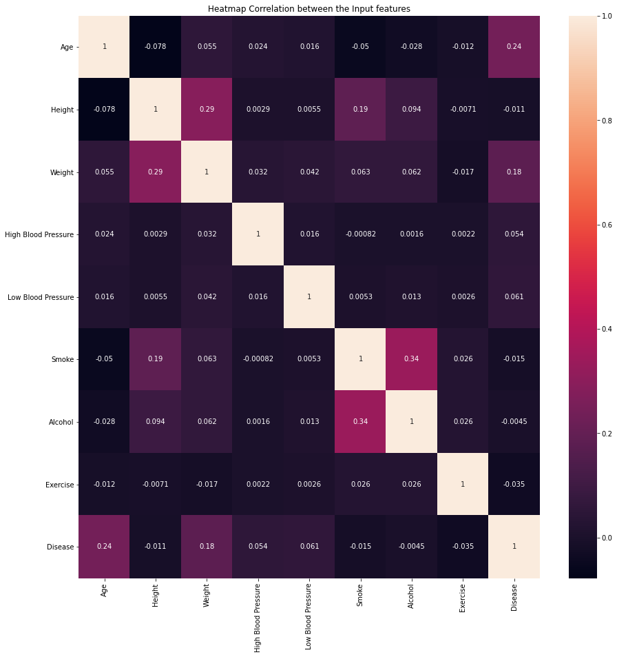

```python
plt.figure(figsize=(15,15))
sns.heatmap(df.corr(), annot=True) # Correlation between the Columns to find the highly correlated columns to remove multi-collinearity
plt.title('Heatmap Correlation between the Input features')
```

**From the correlation between the input features, we can see that the target variable is most related to Age and after that with Weight. Disease risk would be higher for people whose age is more. As the person becomes older, the chances of getting the disease increase as is the case for weight. With increase in weight, disease chances increase. Smoke and Alcohol are related to each other with highest positive correaltion of 0.34.**

**Checking for Imbalance in the dataset (Target Variable)**

```python
df.Disease.value_counts(normalize=True)
```

```
0    0.500041
1    0.499959
Name: Disease, dtype: float64
```

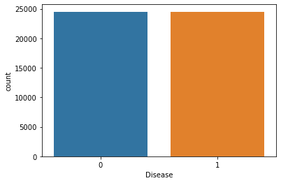

```python
sns.countplot(x='Disease',data=df)
```

**Target Variable which we are predicting is balanced**

**2. Checking for the duplicate values**

```python
df.drop_duplicates(keep='first',inplace=True)
```

```python
print('Number of duplicate records are',49000 - df.shape[0])
```

```
Number of duplicate records are 1752
```

```python
df.shape
```

```
(47248, 12)
```

**3. Outlier Detection and Handling**

```python
df.describe()
```

|  | Age | Height | Weight | High Blood Pressure | Low Blood Pressure | Smoke | Alcohol | Exercise | Disease |
| --- | --- | --- | --- | --- | --- | --- | --- | --- | --- |
| count | 47248.000000 | 47248.000000 | 47248.000000 | 47248.000000 | 47248.000000 | 47248.000000 | 47248.000000 | 47248.000000 | 47248.000000 |
| mean | 52.863126 | 164.352735 | 74.442470 | 129.013461 | 97.557209 | 0.091411 | 0.056235 | 0.799378 | 0.509567 |
| std | 6.791208 | 8.314608 | 14.469526 | 150.324461 | 204.020137 | 0.288196 | 0.230378 | 0.400470 | 0.499914 |
| min | 29.000000 | 55.000000 | 10.000000 | -150.000000 | 0.000000 | 0.000000 | 0.000000 | 0.000000 | 0.000000 |
| 25% | 48.000000 | 159.000000 | 65.000000 | 120.000000 | 80.000000 | 0.000000 | 0.000000 | 1.000000 | 0.000000 |
| 50% | 53.000000 | 165.000000 | 72.000000 | 120.000000 | 80.000000 | 0.000000 | 0.000000 | 1.000000 | 1.000000 |
| 75% | 58.000000 | 170.000000 | 82.000000 | 140.000000 | 90.000000 | 0.000000 | 0.000000 | 1.000000 | 1.000000 |
| max | 64.000000 | 207.000000 | 200.000000 | 14020.000000 | 11000.000000 | 1.000000 | 1.000000 | 1.000000 | 1.000000 |

### Although the data seems clean without missing values, there are outliers and data quality issues which can be seen clearly.

```python
# Function to clip the upper and lower bounds of data in a column with unusual data values

def clip_max_min(df,col,max_val,min_val):
    df[col][df[col] > max_val] = max_val
    df[col][df[col] < min_val] = min_val
```

### Height Column Values Correction

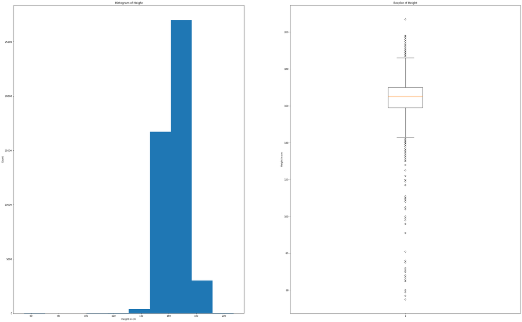

```python
plt.figure(figsize=(40,25))
plt.subplot(1,2,1)
plt.hist(df.Height,histtype='bar')
plt.xlabel('Height in cm')
plt.ylabel('Count')
plt.title('Histogram of Height')

plt.subplot(1,2,2)
plt.boxplot(df.Height)
plt.ylabel('Height in cm')
plt.title('Boxplot of Height')

plt.show()
```

```python
clip_max_min(df,'Height',200,125)
```

```python
clip_max_min(df_test,'Height',200,125)
```

**Clipping the Minimum Height value at 125 cm and maximum height at 200 cm. For adults of age between 30 to 65, height of people would range in between these 2 values.**

### Weight Column Values Correction

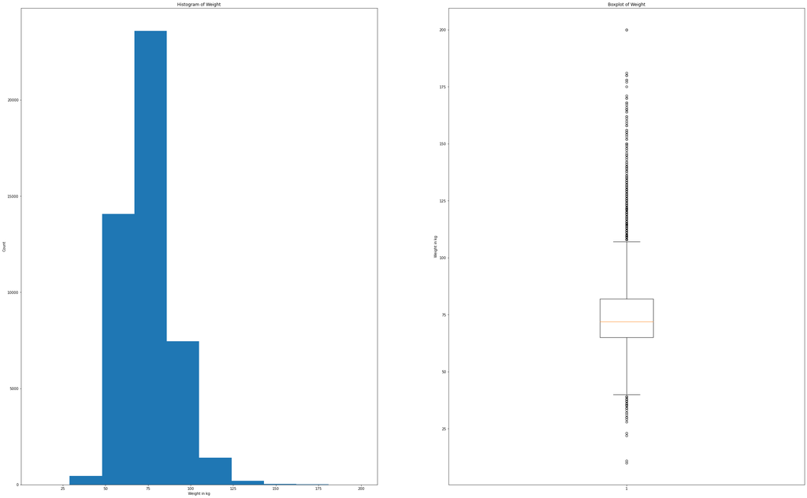

```python
plt.figure(figsize=(40,25))
plt.subplot(1,2,1)
plt.hist(df.Weight,histtype='bar')
plt.xlabel('Weight in kg')
plt.ylabel('Count')
plt.title('Histogram of Weight')

plt.subplot(1,2,2)
plt.boxplot(df.Weight)
plt.ylabel('Weight in kg')
plt.title('Boxplot of Weight')

plt.show()
```

```python
clip_max_min(df,'Weight',180,40)
```

```python
clip_max_min(df_test,'Weight',180,40)
```

**Clipping the Minimum Weight value at 40 kg and maximum weight at 180 kg. For adults of age between 30 to 65, weight of people would range in between these 2 values and would rarely go beyonf this range.**

### Creating New Feature BMI (Body Mass Index)

**BMI is calculated based on weight and height and it tells whether the person is obese or healthy or overweight. If we know that person is healthy, the chances of getting the disease reduces whereas if the person is overweight or obese, his/her chances of getting the disease increase to be higher probability. So, BMI is very helpful and our models like Random Forest and GBM would tell us if we are right based on the feature importances indicating if BMI is contributing significantly or not in model's disease prediction.**

```python
df['BMI'] = df["Weight"]/ (df["Height"]/100)**2
```

```python
df_test['BMI'] = df_test["Weight"]/ (df_test["Height"]/100)**2
```

### BMI Index Values Correction

```python
bmi_filter = ((df['BMI'] < 10) | (df['BMI'] > 60))
```

```python
df = df[~bmi_filter]
```

**Filtering the BMI Index values below 10 and above 60 as these are the cases of extreme outliers based on the BMI value range in real world. Having BMI beyond this means extreme underweight or overweight which can lead to outliers being present in the data and it happens only in a few cases. So, it would better to remove these rows.**

```python
df.shape
```

```
(47229, 13)
```

### High Blood Pressure Values Correction

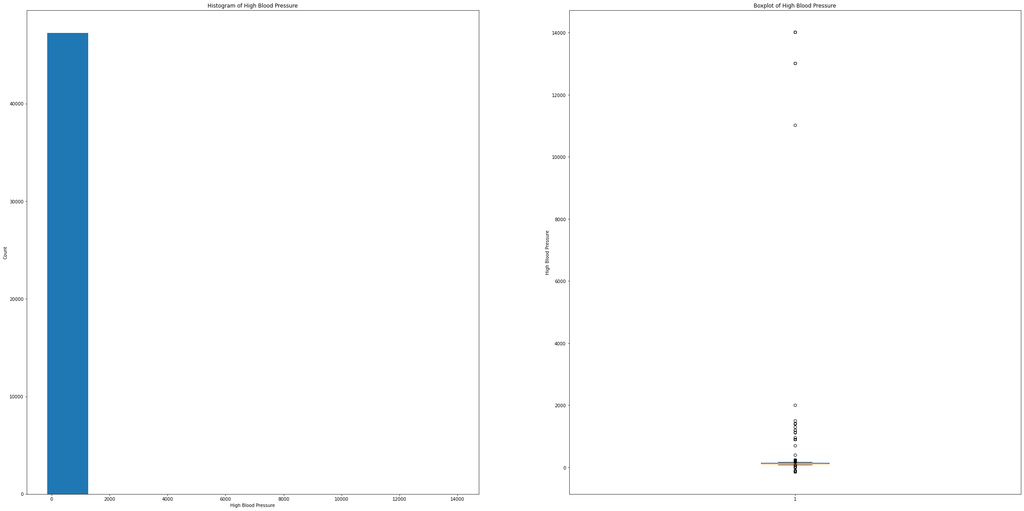

```python
plt.figure(figsize=(40,20))
plt.subplot(1,2,1)
plt.hist(df['High Blood Pressure'],histtype='bar')
plt.xlabel('High Blood Pressure')
plt.ylabel('Count')
plt.title('Histogram of High Blood Pressure')

plt.subplot(1,2,2)
plt.boxplot(df['High Blood Pressure'])
plt.ylabel('High Blood Pressure')
plt.title('Boxplot of High Blood Pressure')

plt.show()
```

```python
clip_max_min(df,'High Blood Pressure',200,60)
```

```python
clip_max_min(df_test,'High Blood Pressure',200,60)
```

**Clipping the values of High Blood Pressure to range between 200 maximum and 60 minimum based on the values for their range as accepted by the medical professionals. The High Blood Pressure which is known as Systolic Blood Pressure in Medical Terms has the range of 90 to 120 for normal blood pressure. Anything below that or higher than that would increase the risk of disease.**

### Low Blood Pressure Values Correction

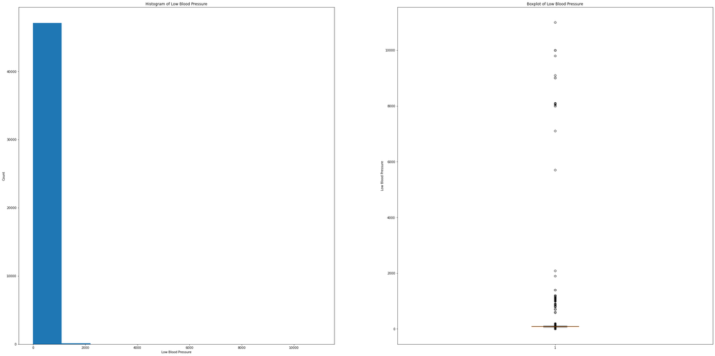

```python
plt.figure(figsize=(40,20))
plt.subplot(1,2,1)
plt.hist(df['Low Blood Pressure'],histtype='bar')
plt.xlabel('Low Blood Pressure')
plt.ylabel('Count')
plt.title('Histogram of Low Blood Pressure')

plt.subplot(1,2,2)
plt.boxplot(df['Low Blood Pressure'])
plt.ylabel('Low Blood Pressure')
plt.title('Boxplot of Low Blood Pressure')

plt.show()
```

```python
clip_max_min(df,'Low Blood Pressure',130,50)
```

```python
clip_max_min(df_test,'Low Blood Pressure',130,50)
```

**Clipping the values of Low Blood Pressure to range between 130 maximum and 50 minimum based on the values for their range as accepted by the medical professionals. The Low Blood Pressure which is known as Diastolic Blood Pressure in Medical Terms has the range of 60 to 80 for normal blood pressure. Anything below that or higher than that would increase the risk of disease.**

### Checking if the High Blood Pressure Values are greater than Lower Pressure Values

```python
df[df['High Blood Pressure'] < df['Low Blood Pressure']]
```

|  | Age | Gender | Height | Weight | High Blood Pressure | Low Blood Pressure | Cholesterol | Glucose | Smoke | Alcohol | Exercise | Disease | BMI |
| --- | --- | --- | --- | --- | --- | --- | --- | --- | --- | --- | --- | --- | --- |
| 409 | 53 | male | 158 | 61.0 | 60 | 80 | too high | too high | 0 | 0 | 1 | 0 | 24.435187 |
| 441 | 40 | male | 188 | 96.0 | 80 | 130 | normal | normal | 0 | 1 | 1 | 0 | 27.161612 |
| 671 | 48 | male | 173 | 78.0 | 90 | 130 | normal | normal | 0 | 1 | 1 | 1 | 26.061679 |
| 905 | 48 | female | 125 | 45.0 | 60 | 80 | normal | normal | 0 | 0 | 1 | 0 | 28.800000 |
| 1018 | 42 | female | 152 | 60.0 | 60 | 80 | normal | normal | 0 | 0 | 1 | 0 | 25.969529 |
| ... | ... | ... | ... | ... | ... | ... | ... | ... | ... | ... | ... | ... | ... |
| 47917 | 52 | male | 166 | 95.0 | 60 | 90 | normal | normal | 0 | 0 | 0 | 1 | 34.475250 |
| 47977 | 56 | female | 167 | 72.0 | 60 | 80 | normal | normal | 0 | 0 | 1 | 1 | 25.816630 |
| 47985 | 61 | female | 162 | 72.0 | 80 | 130 | too high | too high | 0 | 0 | 1 | 1 | 27.434842 |
| 48165 | 58 | female | 155 | 69.0 | 60 | 90 | normal | too high | 0 | 0 | 1 | 1 | 28.720083 |
| 48714 | 52 | female | 170 | 85.0 | 60 | 90 | normal | normal | 0 | 0 | 1 | 1 | 29.411765 |

228 rows × 13 columns

**There are 228 rows where High Blood Pressure is lower than Low Blood Pressure. This is not possible according to the Medical Science. We cannot have High Blood Pressure lower than Low Blood Pressure. So, this may be data quality issue which could be solved only by reversing the values for High and Low Blood Pressure where High Blood Pressure is lower than Low Blood Pressure.**

```python
# Function to reverse the values in High and Low Blood Pressure if High Blood Pressure < Low Blood Pressure

def pressure_reverse(df,col1,col2):
    cond = df[col1] < df[col2]
    df.loc[cond, [col1, col2]] = df.loc[cond, [col2, col1]].values
```

```python
pressure_reverse(df,'High Blood Pressure','Low Blood Pressure')
```

```python
df[df['High Blood Pressure'] < df['Low Blood Pressure']]
```

|  | Age | Gender | Height | Weight | High Blood Pressure | Low Blood Pressure | Cholesterol | Glucose | Smoke | Alcohol | Exercise | Disease | BMI |
| --- | --- | --- | --- | --- | --- | --- | --- | --- | --- | --- | --- | --- | --- |

```python
pressure_reverse(df_test,'High Blood Pressure','Low Blood Pressure')
```

```python
df_test.shape
```

```
(21000, 13)
```

```python
df.describe()
```

|  | Age | Height | Weight | High Blood Pressure | Low Blood Pressure | Smoke | Alcohol | Exercise | Disease | BMI |
| --- | --- | --- | --- | --- | --- | --- | --- | --- | --- | --- |
| count | 47229.000000 | 47229.000000 | 47229.000000 | 47229.000000 | 47229.000000 | 47229.000000 | 47229.000000 | 47229.000000 | 47229.000000 | 47229.000000 |
| mean | 52.861970 | 164.391751 | 74.413314 | 127.230303 | 81.964513 | 0.091406 | 0.056237 | 0.799339 | 0.509496 | 27.578421 |
| std | 6.791741 | 8.057371 | 14.344451 | 17.388207 | 11.150947 | 0.288188 | 0.230381 | 0.400499 | 0.499915 | 5.266484 |
| min | 29.000000 | 125.000000 | 40.000000 | 60.000000 | 50.000000 | 0.000000 | 0.000000 | 0.000000 | 0.000000 | 12.624669 |
| 25% | 48.000000 | 159.000000 | 65.000000 | 120.000000 | 80.000000 | 0.000000 | 0.000000 | 1.000000 | 0.000000 | 23.875433 |
| 50% | 53.000000 | 165.000000 | 72.000000 | 120.000000 | 80.000000 | 0.000000 | 0.000000 | 1.000000 | 1.000000 | 26.562500 |
| 75% | 58.000000 | 170.000000 | 82.000000 | 140.000000 | 90.000000 | 0.000000 | 0.000000 | 1.000000 | 1.000000 | 30.427198 |
| max | 64.000000 | 200.000000 | 180.000000 | 200.000000 | 130.000000 | 1.000000 | 1.000000 | 1.000000 | 1.000000 | 59.523810 |

## All the data quality issues are resolved including the outliers, data entry or collection issues to make our data as clean and accurate to help models make accurate prediction.

# EDA

### Bivariate Analysis

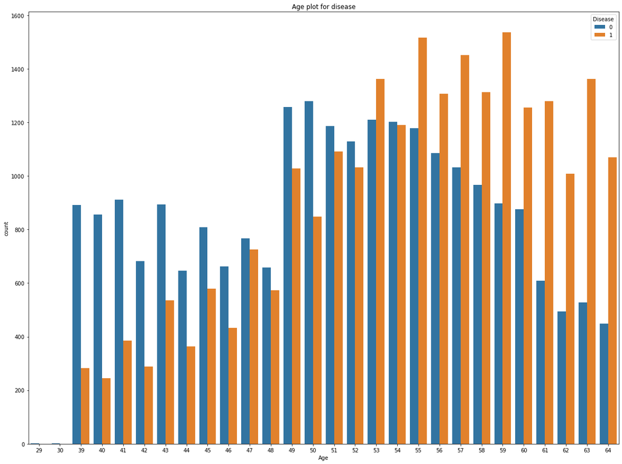

```python
plt.figure(figsize=(20,15))
sns.countplot(hue = df['Disease'], x = df['Age'])
plt.title('Age plot for disease')
```

**It can be seen that the risk of disease gets higher with the increasing age. For the people in their 50's the risk is higher than people who are in their 40's and the Seniors who are 60 or above have the highest chances of getting the disease.**

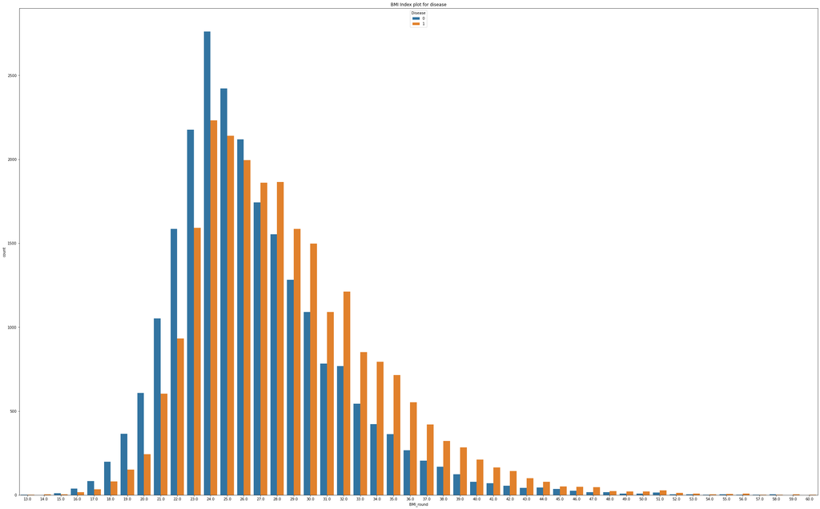

```python
df1 = df.copy()
plt.figure(figsize=(40,25))
df1['BMI_round'] = df1.BMI.round()
sns.countplot(x='BMI_round',hue='Disease',data=df1)
plt.title('BMI Index plot for disease')
```

**BMI Index values greater than 25 indicate Obesity and increase the risk of getting the disease. If the people are very obese they would have issues with their metabolism and also have high risk than people who are healthy to get disease.**

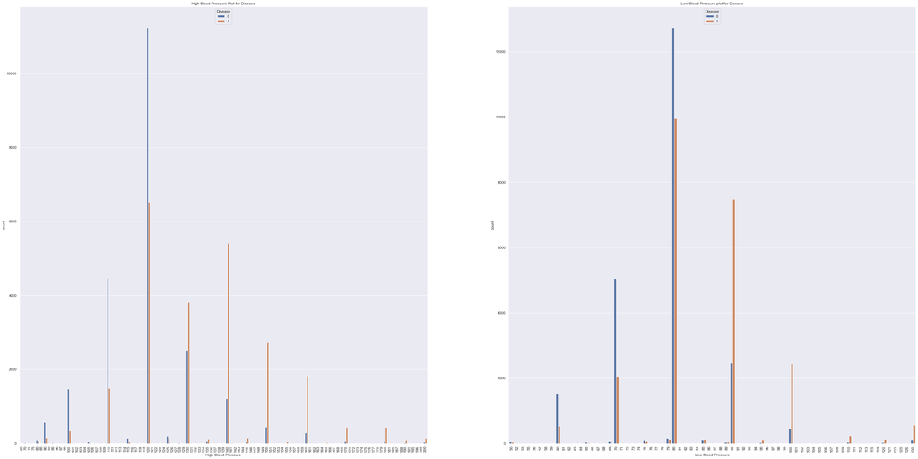

```python
plt.figure(figsize=(50,25))
sns.set(font_scale = 1)
plt.subplot(1,2,1)
sns.countplot(x='High Blood Pressure',hue='Disease',data=df)
plt.xticks(rotation=90)
plt.title('High Blood Pressure Plot for Disease')
plt.subplot(1,2,2)
sns.countplot(x='Low Blood Pressure',hue='Disease',data=df)
plt.xticks(rotation=90)
plt.title('Low Blood Pressure plot for Disease')
```

### Tri Variate Analysis

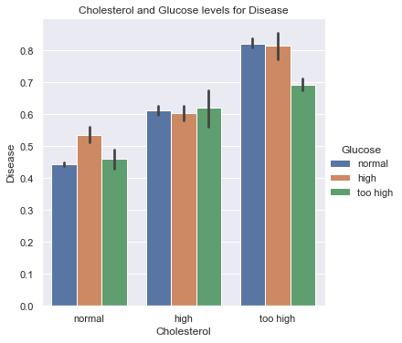

```python
plt.figure(figsize=(20,10))
sns.catplot(x='Cholesterol',y='Disease',hue='Glucose',data=df,kind='bar')
plt.title('Cholesterol and Glucose levels for Disease')
```

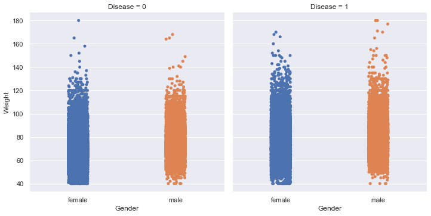

```python
plt.figure(figsize=(60,15))
sns.catplot(x='Gender',y='Weight',col='Disease',data=df)
```

**Taking Weight and Gender into consideration we can see that when the weight increases beyond 120 kg the chances of contracting the disease become higher. People who are overweight or obese are always at more risk of getting diseases than those who are healthy.**  
**Gender disease distribution based on the weight is not very different for male or female. Both males and females seem to have the same vulnerability of getting the disease considering weight as an additional feature.**

### Multi Variate Analysis

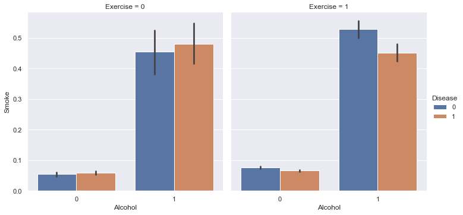

```python
plt.figure(figsize=(20,15))
sns.catplot(hue = 'Disease', x = 'Alcohol', y='Smoke', kind="bar", col='Exercise', data =df)
```

# Data Pre-processing for Modeling

### One Hot Encoding Categorical Attributes and Scaling the Numerical Attributes

**Glucose, Cholesterol and Gender Categorical columns cannot be handles by the algorithms so we need to convert these categorical columns to numerical columns for feeding them as input to the Machine Learning Models. To convert categorical columns to numerical columns, One hot Encoding or Dummies is done.**  
**For N categories we can represent the column using N-1 values for one hot encoding. The dropped value is considered to be default. For example, in Gender if we have 1 dummy column gender_male = 0 implies that the gender is female whereas gender_male=1 indicates male so instead of N columns we would have N-1 columns.**

```python
# Function to do one hot encoding by creating N-1 dummies and dropping the original column

def dummies(df,col):
    return pd.get_dummies(df[col],prefix=col,drop_first=True).join(df).drop([col],axis=1)
```

```python
# Dummy creation for Gender Feature for Train Data

df_onehot = dummies(df,'Gender')
```

```python
# Dummy creation for Cholesterol Feature for Train Data

df_onehot = dummies(df_onehot,'Cholesterol')
```

```python
# Dummy creation for Glucose Feature for Train Data

df_onehot = dummies(df_onehot,'Glucose')
```

```python
df_onehot.head()
```

|  | Glucose_normal | Glucose_too high | Cholesterol_normal | Cholesterol_too high | Gender_male | Age | Height | Weight | High Blood Pressure | Low Blood Pressure | Smoke | Alcohol | Exercise | Disease | BMI |
| --- | --- | --- | --- | --- | --- | --- | --- | --- | --- | --- | --- | --- | --- | --- | --- |
| 0 | 1 | 0 | 1 | 0 | 0 | 59 | 167 | 88.0 | 130 | 68 | 0 | 0 | 1 | 0 | 31.553659 |
| 1 | 1 | 0 | 1 | 0 | 0 | 64 | 150 | 71.0 | 140 | 100 | 0 | 0 | 0 | 1 | 31.555556 |
| 2 | 1 | 0 | 1 | 0 | 0 | 41 | 166 | 83.0 | 100 | 70 | 0 | 1 | 1 | 0 | 30.120482 |
| 3 | 1 | 0 | 1 | 0 | 1 | 50 | 172 | 110.0 | 130 | 80 | 1 | 0 | 1 | 0 | 37.182261 |
| 4 | 0 | 0 | 0 | 0 | 0 | 39 | 162 | 61.0 | 110 | 80 | 0 | 0 | 1 | 0 | 23.243408 |

```python
df_onehot.columns.values
```

```
array(['Glucose_normal', 'Glucose_too high', 'Cholesterol_normal',
       'Cholesterol_too high', 'Gender_male', 'Age', 'Height', 'Weight',
       'High Blood Pressure', 'Low Blood Pressure', 'Smoke', 'Alcohol',
       'Exercise', 'Disease', 'BMI'], dtype=object)
```

```python
cols = ['Glucose_normal', 'Glucose_too high', 'Cholesterol_normal',
       'Cholesterol_too high', 'Gender_male', 'Age', 'Height', 'Weight',
       'High Blood Pressure', 'Low Blood Pressure', 'Smoke', 'Alcohol',
       'Exercise', 'BMI','Disease']
```

```python
# Reversing the BMI and Disease column positions in train data

df_onehot = df_onehot[cols]
```

```python
df_onehot.shape
```

```
(47229, 15)
```

**Normalizing/Scaling the Data for the KNN and SVM as distances are calculated so we want to make all the attributes on the same scale for the algorithm to be not biased to one input feature or the other**

```python
# MinMax Scaling for the Train Data to make all the input features on same scale

min_max_scaler = preprocessing.MinMaxScaler()
train_scaled = min_max_scaler.fit_transform(df_onehot)
```

```python
# Creating the Normalized Train Data

df_normalized = pd.DataFrame(train_scaled, columns=df_onehot.columns, index=df_onehot.index)
df_normalized.head()
```

|  | Glucose_normal | Glucose_too high | Cholesterol_normal | Cholesterol_too high | Gender_male | Age | Height | Weight | High Blood Pressure | Low Blood Pressure | Smoke | Alcohol | Exercise | BMI | Disease |
| --- | --- | --- | --- | --- | --- | --- | --- | --- | --- | --- | --- | --- | --- | --- | --- |
| 0 | 1.0 | 0.0 | 1.0 | 0.0 | 0.0 | 0.857143 | 0.560000 | 0.342857 | 0.500000 | 0.225 | 0.0 | 0.0 | 1.0 | 0.403611 | 0.0 |
| 1 | 1.0 | 0.0 | 1.0 | 0.0 | 0.0 | 1.000000 | 0.333333 | 0.221429 | 0.571429 | 0.625 | 0.0 | 0.0 | 0.0 | 0.403651 | 1.0 |
| 2 | 1.0 | 0.0 | 1.0 | 0.0 | 0.0 | 0.342857 | 0.546667 | 0.307143 | 0.285714 | 0.250 | 0.0 | 1.0 | 1.0 | 0.373052 | 0.0 |
| 3 | 1.0 | 0.0 | 1.0 | 0.0 | 1.0 | 0.600000 | 0.626667 | 0.500000 | 0.500000 | 0.375 | 1.0 | 0.0 | 1.0 | 0.523626 | 0.0 |
| 4 | 0.0 | 0.0 | 0.0 | 0.0 | 0.0 | 0.285714 | 0.493333 | 0.150000 | 0.357143 | 0.375 | 0.0 | 0.0 | 1.0 | 0.226417 | 0.0 |

### Dummies Creation and Normalizing Test Data

```python
# Dummy creation for Gender Feature for Test Data

df_onehot_test = dummies(df_test,'Gender')
```

```python
# Dummy creation for Cholesterol Feature for Test Data

df_onehot_test = dummies(df_onehot_test,'Cholesterol')
```

```python
# Dummy creation for Glucose Feature for Test Data

df_onehot_test = dummies(df_onehot_test,'Glucose')
```

```python
df_onehot_test.shape
```

```
(21000, 15)
```

```python
# MinMax Scaling for the Test Data to make all the input features on same scale

min_max_scaler = preprocessing.MinMaxScaler()
test_scaled = min_max_scaler.fit_transform(df_onehot_test)
```

```python
# Creating the Normalized Test Data

df_normalized_test = pd.DataFrame(test_scaled, columns=df_onehot_test.columns, index=df_onehot_test.index)
df_normalized_test.head()
```

|  | Glucose_normal | Glucose_too high | Cholesterol_normal | Cholesterol_too high | Gender_male | ID | Age | Height | Weight | High Blood Pressure | Low Blood Pressure | Smoke | Alcohol | Exercise | BMI |
| --- | --- | --- | --- | --- | --- | --- | --- | --- | --- | --- | --- | --- | --- | --- | --- |
| 0 | 1.0 | 0.0 | 0.0 | 0.0 | 0.0 | 0.000000 | 0.428571 | 0.466667 | 0.135714 | 0.285714 | 0.375 | 0.0 | 0.0 | 1.0 | 0.094882 |
| 1 | 1.0 | 0.0 | 1.0 | 0.0 | 0.0 | 0.000048 | 0.342857 | 0.586667 | 0.242857 | 0.428571 | 0.250 | 0.0 | 0.0 | 1.0 | 0.123394 |
| 2 | 0.0 | 0.0 | 1.0 | 0.0 | 1.0 | 0.000095 | 0.971429 | 0.573333 | 0.314286 | 0.428571 | 0.375 | 0.0 | 0.0 | 1.0 | 0.161765 |
| 3 | 1.0 | 0.0 | 1.0 | 0.0 | 0.0 | 0.000143 | 0.742857 | 0.440000 | 0.485714 | 0.714286 | 0.625 | 0.0 | 0.0 | 0.0 | 0.296232 |
| 4 | 1.0 | 0.0 | 1.0 | 0.0 | 0.0 | 0.000190 | 0.742857 | 0.560000 | 0.192857 | 0.428571 | 0.375 | 0.0 | 0.0 | 1.0 | 0.104612 |

```python
df_normalized_test['ID'] = df_test['ID']
```

```python
df_normalized_test.head()
```

|  | Glucose_normal | Glucose_too high | Cholesterol_normal | Cholesterol_too high | Gender_male | ID | Age | Height | Weight | High Blood Pressure | Low Blood Pressure | Smoke | Alcohol | Exercise | BMI |
| --- | --- | --- | --- | --- | --- | --- | --- | --- | --- | --- | --- | --- | --- | --- | --- |
| 0 | 1.0 | 0.0 | 0.0 | 0.0 | 0.0 | 0 | 0.428571 | 0.466667 | 0.135714 | 0.285714 | 0.375 | 0.0 | 0.0 | 1.0 | 0.094882 |
| 1 | 1.0 | 0.0 | 1.0 | 0.0 | 0.0 | 1 | 0.342857 | 0.586667 | 0.242857 | 0.428571 | 0.250 | 0.0 | 0.0 | 1.0 | 0.123394 |
| 2 | 0.0 | 0.0 | 1.0 | 0.0 | 1.0 | 2 | 0.971429 | 0.573333 | 0.314286 | 0.428571 | 0.375 | 0.0 | 0.0 | 1.0 | 0.161765 |
| 3 | 1.0 | 0.0 | 1.0 | 0.0 | 0.0 | 3 | 0.742857 | 0.440000 | 0.485714 | 0.714286 | 0.625 | 0.0 | 0.0 | 0.0 | 0.296232 |
| 4 | 1.0 | 0.0 | 1.0 | 0.0 | 0.0 | 4 | 0.742857 | 0.560000 | 0.192857 | 0.428571 | 0.375 | 0.0 | 0.0 | 1.0 | 0.104612 |

# **Model Building**

**Metric Used: I am using Accuracy and Recall as the metric to tune and predict the disease. It is important to reduce the number of False Negatives which is percent of times Disease is true and our model predicts it correctly. Even though the person doesn't have disease but we do not want to predict no disease when the person has disease. It is better to predict a person having disease rather than no disease which may lead to later more complications. Accuracy is used to tune the model as we have a balanced dataset and it gives better stable results on test data as the models tuned using accuracy give better recall results**

**Cross Validation is used to build generalized models using 5 fold CV. Data is split in 70:30 ratio for train and test data.**

**GridSearchCV is used for tunning the hyper parameters from a range of values for each of the parameter in the tune grid. This is a brute force method where all the combinations are tried one after the other and sometimes it takes very long for tunning the hyper parameters to get the best tuned model.**

```python
def roc_auc(model,model_name):
    # Plotting the ROC Curve

    # generate a no skill prediction (majority class)
    ns_probs = [0 for _ in range(len(y_test))]

    # predict probabilities
    lr_probs = model.predict_proba(X_test)
    # keep probabilities for the positive outcome only
    lr_probs = lr_probs[:, 1]
    # calculate scores
    ns_auc = roc_auc_score(y_test, ns_probs)
    lr_auc = roc_auc_score(y_test, lr_probs)
    # summarize scores
    print('No Skill: ROC AUC=%.3f' % (ns_auc))
    print('{}: ROC AUC=%.3f'.format(model_name) % (lr_auc))
    # calculate roc curves
    ns_fpr, ns_tpr, _ = roc_curve(y_test, ns_probs)
    lr_fpr, lr_tpr, _ = roc_curve(y_test, lr_probs)
    # plot the roc curve for the model
    plt.figure(figsize=(8,4))
    plt.plot(ns_fpr, ns_tpr, linestyle='--', label='No Skill')
    plt.plot(lr_fpr, lr_tpr, marker='.', label=model_name)
    # axis labels
    plt.xlabel('False Positive Rate')
    plt.ylabel('True Positive Rate')
    plt.title('ROC curve for ' + model_name)
    # show the legend
    plt.legend()
    # show the plot
    plt.show()
```

# Decision Tree

```python
X = df_onehot.drop(['Disease'],axis=1)
y = df_onehot['Disease']
```

```python
X_train, X_test, y_train, y_test =  train_test_split(X, y, test_size=0.3, random_state=16)
```

```python
dtree = DecisionTreeClassifier()
```

```python
dtree.fit(X_train,y_train)
```

```
DecisionTreeClassifier()
```

```python
dtree_pred = dtree.predict(X_test)
```

```python
print(f"Accuracy: {round(metrics.accuracy_score(y_test, dtree_pred)*100, 2)}%")
```

```
Accuracy: 62.73%
```

```python
print(confusion_matrix(y_test,dtree_pred))
print(classification_report(y_test,dtree_pred))
```

```
[[4361 2614]
 [2667 4527]]
              precision    recall  f1-score   support

           0       0.62      0.63      0.62      6975
           1       0.63      0.63      0.63      7194

    accuracy                           0.63     14169
   macro avg       0.63      0.63      0.63     14169
weighted avg       0.63      0.63      0.63     14169
```

### Decision Tree Hyper Tunning

**Hyper parameters which are tuned for the Decision Tree are:**  
**1. Criterion: This hyper parameter can have 2 values "Gini" or "Entropy". This is the criteria used to split the node using either of the 2 options.**  
**2. Min_Samples_split: The minimum number of samples/instances required to split a node of the decision tree. This parameter ensures that we satisfy the condition of minimum number of instances before splitting a node.**  
**3. Max_depth: This parameter specifies how deep the Decision Tree can be be to its maximum depth. The more deeper is the tree, the more number of splits it takes capturing more information about the data.**  
**4. Min_Samples_leaf: It is the minimum number of samples required by the node to be considered as the leaf node. This is the minimum number of samples required on both the left and right branches for the node to be considered as the leaf node after the split. This parameter may have the effect of smoothing the model.**  
**5. Max_leaf_nodes: Maximum number of the leaf nodes in total at the end of the tree**

```python
param_grid = {'criterion':['gini','entropy'],
              'min_samples_split':[25,100,200],
              'max_depth': [5, 20, 30],
              'min_samples_leaf': [1,3, 5, 10],
              'max_leaf_nodes': [5, 10, 20,40]}
```

```python
dtree_grid = GridSearchCV(dtree, param_grid ,scoring='accuracy',cv = 5,verbose=1,n_jobs=-1)
```

```python
dtree_grid.fit(X_train,y_train)
```

```
Fitting 5 folds for each of 288 candidates, totalling 1440 fits
```

```
[Parallel(n_jobs=-1)]: Using backend LokyBackend with 8 concurrent workers.
[Parallel(n_jobs=-1)]: Done  34 tasks      | elapsed:    3.9s
[Parallel(n_jobs=-1)]: Done 232 tasks      | elapsed:    6.3s
[Parallel(n_jobs=-1)]: Done 732 tasks      | elapsed:   10.9s
[Parallel(n_jobs=-1)]: Done 1440 out of 1440 | elapsed:   18.7s finished
```

```
GridSearchCV(cv=5, estimator=DecisionTreeClassifier(), n_jobs=-1,
             param_grid={'criterion': ['gini', 'entropy'],
                         'max_depth': [5, 20, 30],
                         'max_leaf_nodes': [5, 10, 20, 40],
                         'min_samples_leaf': [1, 3, 5, 10],
                         'min_samples_split': [25, 100, 200]},
             scoring='accuracy', verbose=1)
```

```python
dtree_grid_pred = dtree_grid.predict(X_test)
```

```python
print(f"Accuracy: {round(metrics.accuracy_score(y_test, dtree_grid_pred)*100, 2)}%")
```

```
Accuracy: 72.48%
```

```python
dtree_grid.best_params_
```

```
{'criterion': 'gini',
 'max_depth': 5,
 'max_leaf_nodes': 20,
 'min_samples_leaf': 1,
 'min_samples_split': 25}
```

```python
dtree_grid.best_score_
```

```
0.7309134906231095
```

```python
print(confusion_matrix(y_test,dtree_grid_pred))
print(classification_report(y_test,dtree_grid_pred))
```

```
[[5189 1786]
 [2113 5081]]
              precision    recall  f1-score   support

           0       0.71      0.74      0.73      6975
           1       0.74      0.71      0.72      7194

    accuracy                           0.72     14169
   macro avg       0.73      0.73      0.72     14169
weighted avg       0.73      0.72      0.72     14169
```

```python
dtree_grid_fea_imp = pd.DataFrame({'Features':X_train.columns,'Feature_Importance':dtree_grid.best_estimator_.feature_importances_})
```

```python
dtree_grid_fea_imp = dtree_grid_fea_imp.sort_values(by='Feature_Importance',ascending=False)
```

```python
dtree_grid_fea_imp
```

|  | Features | Feature_Importance |
| --- | --- | --- |
| 8 | High Blood Pressure | 0.786951 |
| 5 | Age | 0.120383 |
| 3 | Cholesterol_too high | 0.069319 |
| 13 | BMI | 0.009311 |
| 1 | Glucose_too high | 0.008029 |
| 10 | Smoke | 0.003364 |
| 2 | Cholesterol_normal | 0.002643 |
| 0 | Glucose_normal | 0.000000 |
| 4 | Gender_male | 0.000000 |
| 6 | Height | 0.000000 |
| 7 | Weight | 0.000000 |
| 9 | Low Blood Pressure | 0.000000 |
| 11 | Alcohol | 0.000000 |
| 12 | Exercise | 0.000000 |

[output not shown]

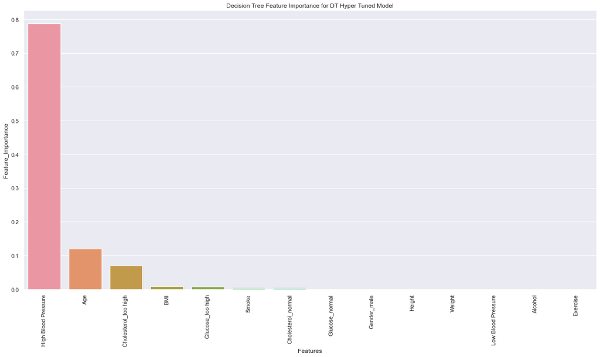

```python
plt.figure(figsize=(20,10))
sns.barplot(x=dtree_grid_fea_imp.Features,y=dtree_grid_fea_imp["Feature_Importance"])
plt.ylabel('Feature_Importance')
plt.title('Decision Tree Feature Importance for DT Hyper Tuned Model')
plt.xticks(rotation=90)
```

**Input features High Blood Pressure, Age, Cholesterol_too_high, BMI, Glucose_too high are the most important features among all the input features. These are the most important features in helping the model to predict the disease accurately. These features make most of the contribution in the model prediction with High Blood Pressure making the biggest contribution. The features such as Height, Weight are given 0 importance which tells that these features do not contribute to the model prediction for Decision Tree.**

```
No Skill: ROC AUC=0.500
DT Grid: ROC AUC=0.788
```

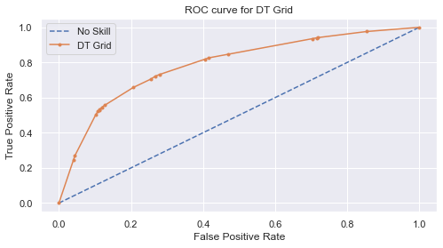

```python
roc_auc(dtree_grid,"DT Grid")
```

**The Hyper tuned Grid DT model has an accuracy of 72%, recall of 71% and AUC score of 0.788.**

```python
dtree_tuned_pred = dtree_grid.predict(df_onehot_test[df_onehot_test.columns[df_onehot_test.columns!="ID"]])
```

# Logistic Regression

```python
X = df_normalized.drop(['Disease'],axis=1)
y = df_normalized['Disease']
```

```python
X_train, X_test, y_train, y_test =  train_test_split(X, y, test_size=0.3, random_state=16)
```

```python
lr = LogisticRegression()
```

```python
lr.fit(X_train, y_train)
```

```
LogisticRegression()
```

```python
lr_pred = lr.predict(X_test)
```

```python
print(f"Accuracy: {round(metrics.accuracy_score(y_test, lr_pred)*100, 2)}%")
```

```
Accuracy: 72.52%
```

```python
print(confusion_matrix(y_test,lr_pred))
print(classification_report(y_test,lr_pred))
```

```
[[5299 1676]
 [2217 4977]]
              precision    recall  f1-score   support

         0.0       0.71      0.76      0.73      6975
         1.0       0.75      0.69      0.72      7194

    accuracy                           0.73     14169
   macro avg       0.73      0.73      0.73     14169
weighted avg       0.73      0.73      0.73     14169
```

### LR Hyper Tunning

**LR Hyper parameters:**

**1. C: It is the Inverse of regularization strength.**  
**2. penalty: It is the norm of the penalization applied either L1 or L2 or Elasticnet. By default, it is L2.**  
**3. solver: Algorithm used in the optimization.**  
**4. warm_start: When set to True, it re-uses previous solution to fit the next initialization. If False, erases previous solution.**

```python
lr.get_params()
```

```
{'C': 1.0,
 'class_weight': None,
 'dual': False,
 'fit_intercept': True,
 'intercept_scaling': 1,
 'l1_ratio': None,
 'max_iter': 100,
 'multi_class': 'auto',
 'n_jobs': None,
 'penalty': 'l2',
 'random_state': None,
 'solver': 'lbfgs',
 'tol': 0.0001,
 'verbose': 0,
 'warm_start': False}
```

```python
param_grid = {'C':[0.1,0.4,0.8,1,0.01,10,100,0.001,5,3],
'penalty': ['l1','l2','elasticnet'],
'solver':['newton-cg', 'lbfgs', 'liblinear', 'sag', 'saga'],
'warm_start': [True,False]}
```

```python
lr_grid = GridSearchCV(lr, param_grid, cv=5,scoring='accuracy',verbose=1, n_jobs=-1)
```

```python
lr_grid.fit(X_train,y_train)
```

```
Fitting 5 folds for each of 300 candidates, totalling 1500 fits
```

```
[Parallel(n_jobs=-1)]: Using backend LokyBackend with 8 concurrent workers.
[Parallel(n_jobs=-1)]: Done  56 tasks      | elapsed:    4.2s
[Parallel(n_jobs=-1)]: Done 411 tasks      | elapsed:   19.7s
[Parallel(n_jobs=-1)]: Done 1006 tasks      | elapsed:  1.4min
[Parallel(n_jobs=-1)]: Done 1500 out of 1500 | elapsed:  2.6min finished
```

```
GridSearchCV(cv=5, estimator=LogisticRegression(), n_jobs=-1,
             param_grid={'C': [0.1, 0.4, 0.8, 1, 0.01, 10, 100, 0.001, 5, 3],
                         'penalty': ['l1', 'l2', 'elasticnet'],
                         'solver': ['newton-cg', 'lbfgs', 'liblinear', 'sag',
                                    'saga'],
                         'warm_start': [True, False]},
             scoring='accuracy', verbose=1)
```

```python
lr_grid_pred = lr_grid.predict(X_test)
```

```python
print(f"Accuracy: {round(metrics.accuracy_score(y_test, lr_grid_pred)*100, 2)}%")
```

```
Accuracy: 72.54%
```

```python
print(confusion_matrix(y_test,lr_grid_pred))
print(classification_report(y_test,lr_grid_pred))
```

```
[[5314 1661]
 [2230 4964]]
              precision    recall  f1-score   support

         0.0       0.70      0.76      0.73      6975
         1.0       0.75      0.69      0.72      7194

    accuracy                           0.73     14169
   macro avg       0.73      0.73      0.73     14169
weighted avg       0.73      0.73      0.73     14169
```

```python
lr_grid.best_params_
```

```
{'C': 0.1, 'penalty': 'l1', 'solver': 'saga', 'warm_start': True}
```

```python
lr_grid.best_score_
```

```
0.729794313369631
```

```
No Skill: ROC AUC=0.500
LR Grid: ROC AUC=0.788
```

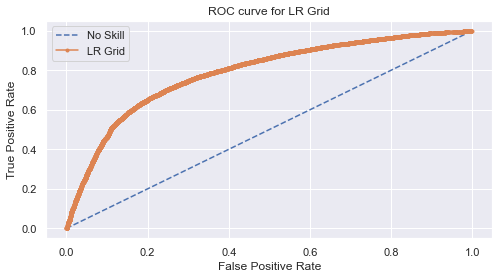

```python
roc_auc(lr_grid,"LR Grid")
```

**The best model for the LR grid has L1 penality used with C value 0.1 and solver used is saga. This model gives an accuracy score of 73% with a recall of 69% and AUC score of 0.788.**

```python
lr_grid_fea_imp = pd.DataFrame({'Features':X_train.columns,'Feature_Importance':np.absolute(lr_grid.best_estimator_.coef_[0])})
```

```python
lr_grid_fea_imp = lr_grid_fea_imp.sort_values(by='Feature_Importance',ascending=False)
```

```python
lr_grid_fea_imp
```

|  | Features | Feature_Importance |
| --- | --- | --- |
| 8 | High Blood Pressure | 7.464464 |
| 5 | Age | 1.767794 |
| 7 | Weight | 1.008448 |
| 9 | Low Blood Pressure | 0.810319 |
| 3 | Cholesterol_too high | 0.655825 |
| 13 | BMI | 0.415320 |
| 2 | Cholesterol_normal | 0.388681 |
| 1 | Glucose_too high | 0.304505 |
| 10 | Smoke | 0.183107 |
| 12 | Exercise | 0.181250 |
| 11 | Alcohol | 0.136427 |
| 4 | Gender_male | 0.019301 |
| 0 | Glucose_normal | 0.000000 |
| 6 | Height | 0.000000 |

**Height and Glucose_normal is eliminated as the coefficient is reduced to 0. L1 Regularization is used to eliminate the features by reducing their coefficients to 0 and L2 Regularization to penalize the high-magnitude coefficients which may lead the model to consider them as more important than other features. So, these 2 features are eleminated by LR due to the L1 penalty. High Blood Pressure increases the chances of disease by the most amount.**

[output not shown]

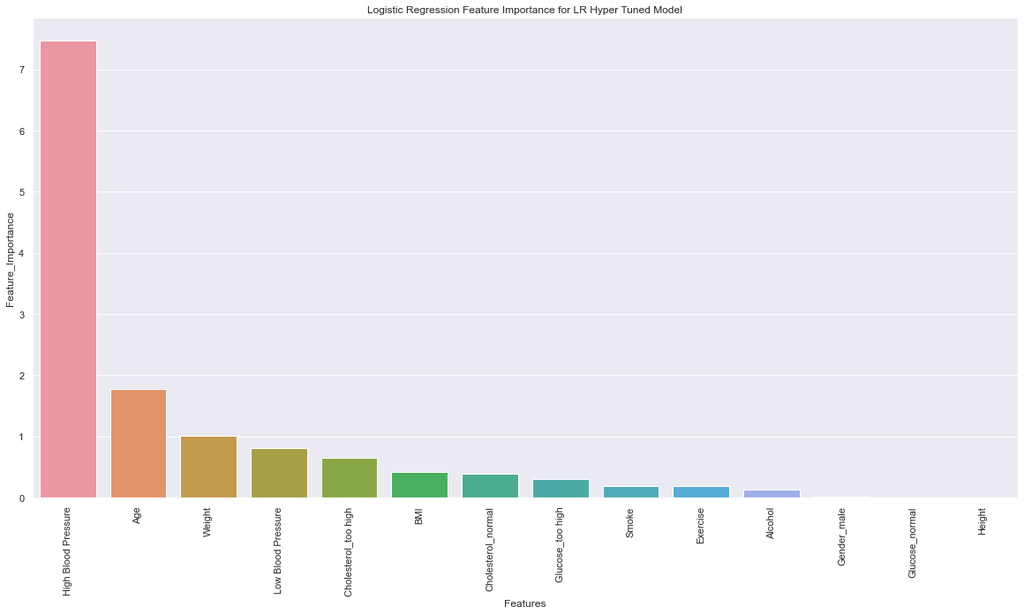

```python
plt.figure(figsize=(20,10))
sns.barplot(x=lr_grid_fea_imp.Features,y=lr_grid_fea_imp["Feature_Importance"])
plt.ylabel('Feature_Importance')
plt.title('Logistic Regression Feature Importance for LR Hyper Tuned Model')
plt.xticks(rotation=90)
```

```python
lr_tuned_pred = lr_grid.predict(df_normalized_test[df_normalized_test.columns[df_normalized_test.columns!="ID"]])
```

# ANN

**Artificial Neural Networks require the input shape and output shape. As this is a binary classification problem, we have single output node and input shape is the same as the number of features in the input. For ANN, all the features need to be numeric. In the output layer, sigmoid activation function is used as it gives the probability of new data point to be classified as disease or not with a probability between 0 and 1. For 1 and 2 hidden layers in the architecture, ReLU activation is used.**

### ANN 0 Hidden Layers

```python
X = df_normalized.drop(['Disease'],axis=1)
y = df_normalized['Disease']
```

```python
X_train, X_test, y_train, y_test =  train_test_split(X, y, test_size=0.3, random_state=16)
```

```python
X_train.shape
```

```
(33060, 14)
```

```python
model_0 = tf.keras.models.Sequential()
model_0.add(Dense(1,activation='sigmoid',input_shape=(14, )))
model_0.output_shape
```

```
(None, 1)
```

```python
model_0.compile(loss='binary_crossentropy', optimizer='sgd', metrics=['accuracy'])
```

```python
model_0.fit(X_train, y_train, epochs=20, batch_size=100, verbose=1)
```

```
<tensorflow.python.keras.callbacks.History at 0x1c582dfc7c0>
```

```python
ann0_pred = np.stack(model_0.predict_classes(X_test),axis=-1)[0]
```

[output not shown]

```python
print(f"Accuracy: {round(metrics.accuracy_score(y_test, ann0_pred)*100, 2)}%")
```

```
Accuracy: 68.43%
```

```python
print(confusion_matrix(y_test,ann0_pred))
print(classification_report(y_test,ann0_pred))
```

```
[[5068 1907]
 [2566 4628]]
              precision    recall  f1-score   support

         0.0       0.66      0.73      0.69      6975
         1.0       0.71      0.64      0.67      7194

    accuracy                           0.68     14169
   macro avg       0.69      0.68      0.68     14169
weighted avg       0.69      0.68      0.68     14169
```

### ANN 0 Hidden Layers Hyper Tunning

**The Hyper parameters tuned for Artificial Neural Networks are:**

**1. Optimizer:Optimizers are algorithms or methods which modify the Neural Network parameters such as weights, biases and learning rate in order to reduce the losses and provide the best possible results as close to the target variable. The various optimizers available are Adam, SGD, RMSprop etc.**  
**2. Batch_size: Batch_size defines the number of input samples/ instances to work through before updating the weights and biases. Mini batch is used here and is mostly used where the number of samples are greater than 1 but less than the input samples. There are multiple batches to iterate once through the whole dataset.**  
**3. epochs: Epochs defines the number of the times that the learning algorithm would iterate through the input training samples. It is the number of complete passes through the training data.**

```python
def model_0hl(optimizer):
    model_ann0 = Sequential()
    model_ann0.add(Dense(1,activation='sigmoid',input_dim=14))
    # Compile model
    model_ann0.compile(loss='binary_crossentropy', optimizer=optimizer, metrics=['accuracy'])
    return model_ann0
```

```python
model_ann0 = KerasClassifier(build_fn=model_0hl)
```

```python
optimizer = ['SGD', 'RMSprop', 'Adam']
batch_size = [50,100, 125, 150]
epochs = [25, 50, 100]
```

```python
param_grid = dict(optimizer=optimizer,batch_size=batch_size,epochs=epochs)
grid_ann0 = GridSearchCV(estimator=model_ann0, param_grid=param_grid, n_jobs=-1, cv=5,scoring='accuracy',verbose=1)
```

```python
grid_ann0.fit(X_train,y_train,validation_data=(X_test,y_test))
```

```
Fitting 5 folds for each of 36 candidates, totalling 180 fits
```

```
[Parallel(n_jobs=-1)]: Using backend LokyBackend with 8 concurrent workers.
[Parallel(n_jobs=-1)]: Done  34 tasks      | elapsed:  5.0min
[Parallel(n_jobs=-1)]: Done 180 out of 180 | elapsed: 15.3min finished
```

```
GridSearchCV(cv=5,
             estimator=<tensorflow.python.keras.wrappers.scikit_learn.KerasClassifier object at 0x000001C587E3BEE0>,
             n_jobs=-1,
             param_grid={'batch_size': [50, 100, 125, 150],
                         'epochs': [25, 50, 100],
                         'optimizer': ['SGD', 'RMSprop', 'Adam']},
             scoring='accuracy', verbose=1)
```

```python
grid_ann0.best_params_
```

```
{'batch_size': 50, 'epochs': 100, 'optimizer': 'Adam'}
```

```python
ann0_grid_pred = np.stack(grid_ann0.predict(X_test),axis=-1)[0]
```

```python
print(f"Accuracy: {round(metrics.accuracy_score(y_test, ann0_grid_pred)*100, 2)}%")
```

```
Accuracy: 72.37%
```

```python
print(confusion_matrix(y_test,ann0_grid_pred))
print(classification_report(y_test,ann0_grid_pred))
```

```
[[5252 1723]
 [2192 5002]]
              precision    recall  f1-score   support

         0.0       0.71      0.75      0.73      6975
         1.0       0.74      0.70      0.72      7194

    accuracy                           0.72     14169
   macro avg       0.72      0.72      0.72     14169
weighted avg       0.72      0.72      0.72     14169
```

```python
model0l = Sequential()
model0l.add(Dense(1,activation='sigmoid',input_shape=(14, )))

model0l.compile(loss='binary_crossentropy', optimizer='Adam', metrics=['accuracy'])
history_0 = model0l.fit(X_train,y_train,batch_size=50,epochs=100,validation_data=(X_test,y_test))
```

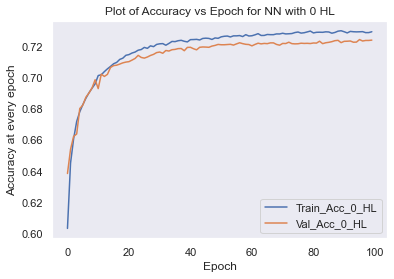

```python
plt.plot(history_0.epoch,history_0.history['accuracy'], label = 'Train_Acc_0_HL')
plt.plot(history_0.epoch,history_0.history['val_accuracy'], label = 'Val_Acc_0_HL')
plt.grid()
plt.ylabel('Accuracy at every epoch')
plt.xlabel('Epoch')
plt.title('Plot of Accuracy vs Epoch for NN with 0 HL')
plt.legend()
```

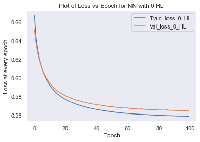

```python
plt.plot(history_0.epoch,history_0.history['loss'], label = 'Train_loss_0_HL')
plt.plot(history_0.epoch,history_0.history['val_loss'], label = 'Val_loss_0_HL')
plt.grid()
plt.ylabel('Loss at every epoch')
plt.xlabel('Epoch')
plt.title('Plot of Loss vs Epoch for NN with 0 HL')
plt.legend()
```

**From the above graphs plotted for Accuracy and Loss over the Epochs, we can see that Accuracy increases with the increase in the epochs whereas the loss decreases with the epoch. Also, we can see that Training and Validation Accuracy as well as Loss are almost the same with Training accuracy slightly higher than validation and training loss slightly lower than validation loss, it can concluded that there is no overfitting or underfitting issue.**  
**The tuned model is able to perform equally well on both training and validation data and is able to generalize.**

```
WARNING:tensorflow:From C:\Users\hites\AppData\Roaming\Python\Python38\site-packages\tensorflow\python\keras\wrappers\scikit_learn.py:264: Sequential.predict_proba (from tensorflow.python.keras.engine.sequential) is deprecated and will be removed after 2021-01-01.
Instructions for updating:
Please use `model.predict()` instead.
No Skill: ROC AUC=0.500
ANN0 Grid: ROC AUC=0.787
```

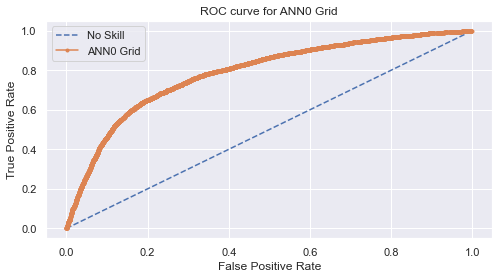

```python
roc_auc(grid_ann0,"ANN0 Grid")
```

**The best tuned AAN0 model gives an accuracy of 72% and Recall of 70% along with AUC score of 0.787.**

```python
ANN0_tuned_pred = np.stack(grid_ann0.predict(df_normalized_test[df_normalized_test.columns[df_normalized_test.columns!="ID"]]),axis=-1)[0]
```

### ANN 1 Hidden Layer

**Single Hidden layer is added to the model. This layer has ReLU as the activation function instead of sigmoid as the activation function. The output from the ReLU activation function is 0 for input values 0 and below and equal to input for positive values.**

```python
model_1 = Sequential()
model_1.add(Dense(21,input_dim=14,activation='relu'))
model_1.add(Dense(1,activation='sigmoid'))
model_1.output_shape
```

```
(None, 1)
```

```python
model_1.summary()
```

```
Model: "sequential_3"
_________________________________________________________________
Layer (type)                 Output Shape              Param #
=================================================================
dense_3 (Dense)              (None, 21)                315
_________________________________________________________________
dense_4 (Dense)              (None, 1)                 22
=================================================================
Total params: 337
Trainable params: 337
Non-trainable params: 0
_________________________________________________________________
```

```python
model_1.compile(loss='binary_crossentropy', optimizer='sgd', metrics=['accuracy'])
```

```python
model_1.fit(X_train, y_train, epochs=20, batch_size=100, verbose=1)
```

```
<tensorflow.python.keras.callbacks.History at 0x1c590870310>
```

```python
ann1_pred = np.stack(model_1.predict_classes(X_test),axis=-1)[0]
```

```python
print(f"Accuracy: {round(metrics.accuracy_score(y_test, ann1_pred)*100, 2)}%")
```

```
Accuracy: 71.05%
```

```python
print(confusion_matrix(y_test,ann1_pred))
print(classification_report(y_test,ann1_pred))
```

```
[[5078 1897]
 [2205 4989]]
              precision    recall  f1-score   support

         0.0       0.70      0.73      0.71      6975
         1.0       0.72      0.69      0.71      7194

    accuracy                           0.71     14169
   macro avg       0.71      0.71      0.71     14169
weighted avg       0.71      0.71      0.71     14169
```

### ANN 1 Hidden Layer Hyper Tunning

**The Hyper parameters tuned for Artificial Neural Networks are:**

**1. Optimizer:Optimizers are algorithms or methods which modify the Neural Network parameters such as weights, biases and learning rate in order to reduce the losses and provide the best possible results as close to the target variable. The various optimizers available are Adam, SGD, RMSprop etc.**  
**2. Batch_size: Batch_size defines the number of input samples/ instances to work through before updating the weights and biases. Mini batch is used here and is mostly used where the number of samples are greater than 1 but less than the input samples. There are multiple batches to iterate once through the whole dataset.**  
**3. epochs: Epochs defines the number of the times that the learning algorithm would iterate through the input training samples. It is the number of complete passes through the training data.**

```python
def model_1hl(optimizer):
    model_ann1 = Sequential()
    model_ann1.add(Dense(21,activation='relu',input_dim=14))
    model_ann1.add(Dense(1,activation='sigmoid'))
    # Compile model
    model_ann1.compile(loss='binary_crossentropy', optimizer=optimizer, metrics=['accuracy'])
    return model_ann1
```

```python
model_ann1 = KerasClassifier(build_fn=model_1hl)
```

```python
param_grid = dict(optimizer=optimizer,batch_size=batch_size,epochs=epochs)
grid_ann1 = GridSearchCV(estimator=model_ann1, param_grid=param_grid, n_jobs=-1, cv=5,scoring='accuracy',verbose=1)
```

```python
grid_ann1.fit(X_train,y_train,validation_data=(X_test,y_test))
```

```
Fitting 5 folds for each of 36 candidates, totalling 180 fits
```

```
[Parallel(n_jobs=-1)]: Using backend LokyBackend with 8 concurrent workers.
[Parallel(n_jobs=-1)]: Done  34 tasks      | elapsed:  5.7min
[Parallel(n_jobs=-1)]: Done 180 out of 180 | elapsed: 18.0min finished
```

```
GridSearchCV(cv=5,
             estimator=<tensorflow.python.keras.wrappers.scikit_learn.KerasClassifier object at 0x000001C590313370>,
             n_jobs=-1,
             param_grid={'batch_size': [50, 100, 125, 150],
                         'epochs': [25, 50, 100],
                         'optimizer': ['SGD', 'RMSprop', 'Adam']},
             scoring='accuracy', verbose=1)
```

```python
grid_ann1.best_params_
```

```
{'batch_size': 50, 'epochs': 100, 'optimizer': 'RMSprop'}
```

```python
ann1_grid_pred = np.stack(grid_ann1.predict(X_test),axis=-1)[0]
```

```python
print(f"Accuracy: {round(metrics.accuracy_score(y_test, ann1_grid_pred)*100, 2)}%")
```

```
Accuracy: 72.94%
```

```python
print(confusion_matrix(y_test,ann1_grid_pred))
print(classification_report(y_test,ann1_grid_pred))
```

```
[[5328 1647]
 [2187 5007]]
              precision    recall  f1-score   support

         0.0       0.71      0.76      0.74      6975
         1.0       0.75      0.70      0.72      7194

    accuracy                           0.73     14169
   macro avg       0.73      0.73      0.73     14169
weighted avg       0.73      0.73      0.73     14169
```

```python
model1l = Sequential()
model1l.add(Dense(21,input_dim=14,activation='relu'))
model1l.add(Dense(1,activation='sigmoid'))

model1l.compile(loss='binary_crossentropy', optimizer='RMSprop', metrics=['accuracy'])
history_1 = model1l.fit(X_train,y_train,batch_size=50,epochs=100,validation_data=(X_test,y_test))
```

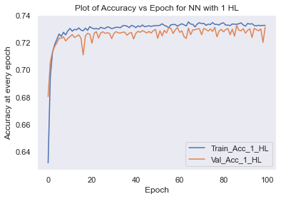

```python
plt.plot(history_1.epoch,history_1.history['accuracy'], label = 'Train_Acc_1_HL')
plt.plot(history_1.epoch,history_1.history['val_accuracy'], label = 'Val_Acc_1_HL')
plt.grid()
plt.ylabel('Accuracy at every epoch')
plt.xlabel('Epoch')
plt.title('Plot of Accuracy vs Epoch for NN with 1 HL')
plt.legend()
```

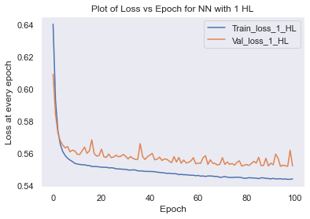

```python
plt.plot(history_1.epoch,history_1.history['loss'], label = 'Train_loss_1_HL')
plt.plot(history_1.epoch,history_1.history['val_loss'], label = 'Val_loss_1_HL')
plt.grid()
plt.ylabel('Loss at every epoch')
plt.xlabel('Epoch')
plt.title('Plot of Loss vs Epoch for NN with 1 HL')
plt.legend()
```

**From the above graphs for Accuracy vs Epochs and Loss vs Epochs, we can see that Accuracy increases with the increase in the epochs whereas the loss decreases with the epochs. Also, we can see that Training and Validation Accuracy as well as Loss are almost the same with Training accuracy slightly doing better than validation and training loss slightly less than validation loss, it can concluded that there is no overfitting or underfitting issue.**  
**The tuned model is able to perform equally well on both training and validation data and nicely generalizes.**  
**From the graphs, it is evident that Loss drops more steeply than with No hidden layers. The loss with 1 Hidden layer is lower than loss with no hidden layer. Accuracy is slightly higher for Model with 1 hidden layer than model with no hidden layer.**

```
No Skill: ROC AUC=0.500
ANN 1 HL Grid: ROC AUC=0.794
```

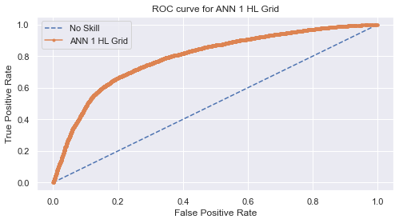

```python
roc_auc(grid_ann1,"ANN 1 HL Grid")
```

**The tuned ANN1 model gives an accuracy of 73% with recall of 70% with an AUC score of 0.794.**

```python
ANN1_tuned_pred = np.stack(grid_ann1.predict(df_normalized_test[df_normalized_test.columns[df_normalized_test.columns!="ID"]]),axis=-1)[0]
```

### ANN 2 Hidden Layers

```python
model_2 = Sequential()
model_2.add(Dense(21,input_dim=14,activation='relu'))
model_2.add(Dense(21,activation='relu'))
model_2.add(Dense(1,activation='sigmoid'))
model_2.output_shape
```

```
(None, 1)
```

```python
model_2.summary()
```

```
Model: "sequential_6"
_________________________________________________________________
Layer (type)                 Output Shape              Param #
=================================================================
dense_9 (Dense)              (None, 21)                315
_________________________________________________________________
dense_10 (Dense)             (None, 21)                462
_________________________________________________________________
dense_11 (Dense)             (None, 1)                 22
=================================================================
Total params: 799
Trainable params: 799
Non-trainable params: 0
_________________________________________________________________
```

```python
model_2.compile(loss='binary_crossentropy', optimizer='sgd', metrics=['accuracy'])
```

```python
model_2.fit(X_train, y_train, epochs=20, batch_size=100, verbose=1)
```

```
<tensorflow.python.keras.callbacks.History at 0x1c595776be0>
```

```python
ann2_pred = np.stack(model_2.predict_classes(X_test),axis=-1)[0]
```

```python
print(f"Accuracy: {round(metrics.accuracy_score(y_test, ann2_pred)*100, 2)}%")
```

```
Accuracy: 72.29%
```

```python
print(confusion_matrix(y_test,ann2_pred))
print(classification_report(y_test,ann2_pred))
```

```
[[5126 1849]
 [2077 5117]]
              precision    recall  f1-score   support

         0.0       0.71      0.73      0.72      6975
         1.0       0.73      0.71      0.72      7194

    accuracy                           0.72     14169
   macro avg       0.72      0.72      0.72     14169
weighted avg       0.72      0.72      0.72     14169
```

### ANN 2 Hidden Layer Hyper Tunning

**The Hyper parameters tuned for Artificial Neural Networks are:**

**1. Optimizer:Optimizers are algorithms or methods which modify the Neural Network parameters such as weights, biases and learning rate in order to reduce the losses and provide the best possible results as close to the target variable. The various optimizers available are Adam, SGD, RMSprop etc.**  
**2. Batch_size: Batch_size defines the number of input samples/ instances to work through before updating the weights and biases. Mini batch is used here and is mostly used where the number of samples are greater than 1 but less than the input samples. There are multiple batches to iterate once through the whole dataset.**  
**3. epochs: Epochs defines the number of the times that the learning algorithm would iterate through the input training samples. It is the number of complete passes through the training data.**

```python
def model_2hl(optimizer):
    model_ann2 = Sequential()
    model_ann2.add(Dense(21,activation='relu',input_dim=14))
    model_ann2.add(Dense(21,activation='relu'))
    model_ann2.add(Dense(1,activation='sigmoid'))
    # Compile model
    model_ann2.compile(loss='binary_crossentropy', optimizer=optimizer, metrics=['accuracy'])
    return model_ann2
```

```python
model_ann2 = KerasClassifier(build_fn=model_2hl)
```

```python
param_grid = dict(optimizer=optimizer,batch_size=batch_size,epochs=epochs)
grid_ann2 = GridSearchCV(estimator=model_ann2, param_grid=param_grid, n_jobs=-1, cv=5,scoring='accuracy',verbose=1)
```

```python
grid_ann2.fit(X_train,y_train,validation_data=(X_test,y_test))
```

```
Fitting 5 folds for each of 36 candidates, totalling 180 fits
```

```
[Parallel(n_jobs=-1)]: Using backend LokyBackend with 8 concurrent workers.
[Parallel(n_jobs=-1)]: Done  34 tasks      | elapsed:  9.2min
[Parallel(n_jobs=-1)]: Done 180 out of 180 | elapsed: 26.7min finished
```

```
GridSearchCV(cv=5,
             estimator=<tensorflow.python.keras.wrappers.scikit_learn.KerasClassifier object at 0x000001C5938A08E0>,
             n_jobs=-1,
             param_grid={'batch_size': [50, 100, 125, 150],
                         'epochs': [25, 50, 100],
                         'optimizer': ['SGD', 'RMSprop', 'Adam']},
             scoring='accuracy', verbose=1)
```

```python
grid_ann2.best_params_
```

```
{'batch_size': 150, 'epochs': 100, 'optimizer': 'Adam'}
```

```python
ann2_grid_pred = np.stack(grid_ann2.predict(X_test),axis=-1)[0]
```

```python
print(f"Accuracy: {round(metrics.accuracy_score(y_test, ann2_grid_pred)*100, 2)}%")
```

```
Accuracy: 72.86%
```

```python
print(confusion_matrix(y_test,ann2_grid_pred))
print(classification_report(y_test,ann2_grid_pred))
```

```
[[5107 1868]
 [1977 5217]]
              precision    recall  f1-score   support

         0.0       0.72      0.73      0.73      6975
         1.0       0.74      0.73      0.73      7194

    accuracy                           0.73     14169
   macro avg       0.73      0.73      0.73     14169
weighted avg       0.73      0.73      0.73     14169
```

```python
model2l = Sequential()
model2l.add(Dense(21,input_dim=14,activation='relu'))
model2l.add(Dense(21,input_dim=14,activation='relu'))
model2l.add(Dense(1,activation='sigmoid'))

model2l.compile(loss='binary_crossentropy', optimizer='Adam', metrics=['accuracy'])
history_2 = model2l.fit(X_train,y_train,batch_size=150,epochs=100,validation_data=(X_test,y_test))
```

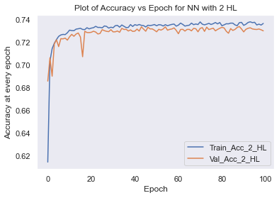

```python
plt.plot(history_2.epoch,history_2.history['accuracy'], label = 'Train_Acc_2_HL')
plt.plot(history_2.epoch,history_2.history['val_accuracy'], label = 'Val_Acc_2_HL')
plt.grid()
plt.ylabel('Accuracy at every epoch')
plt.xlabel('Epoch')
plt.title('Plot of Accuracy vs Epoch for NN with 2 HL')
plt.legend()
```

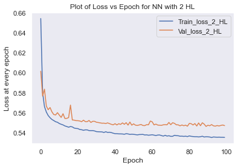

```python
plt.plot(history_2.epoch,history_2.history['loss'], label = 'Train_loss_2_HL')
plt.plot(history_2.epoch,history_2.history['val_loss'], label = 'Val_loss_2_HL')
plt.grid()
plt.ylabel('Loss at every epoch')
plt.xlabel('Epoch')
plt.title('Plot of Loss vs Epoch for NN with 2 HL')
plt.legend()
```

```
No Skill: ROC AUC=0.500
ANN 2 HL Grid: ROC AUC=0.795
```

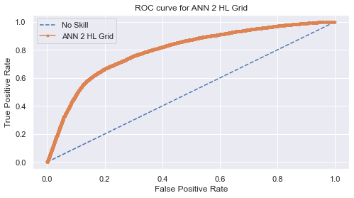

```python
roc_auc(grid_ann2,"ANN 2 HL Grid")
```

**The tuned AAN2 model gives an accuracy of 73% with recall of 73% with an AUC score of 0.795.**

**While tunning the grid for each of the 3 ANN models, the hyperparameter values for optimizer, batch_size and epochs came out to be different even though same set of values were used in the grid. For ANN with 0 Hidden layers and with 2 Hidden layers, best optimizer came out to be Adam whereas for ANN with 1 Hidden layer it came out to be RMSprop.**

```python
ANN2_tuned_pred = np.stack(grid_ann2.predict(df_normalized_test[df_normalized_test.columns[df_normalized_test.columns!="ID"]]),axis=-1)[0]
```